# Ordering effect of the capture sites

Joyce Hsiao & Po-Yuang Tung

2015-09-26

**Last updated:** 2015-09-26

**Code version:** d16ac4ab603098aca0b0b577825dacfb5b01adb1

**Last updated:** 2015-09-28

**Code version:** 3f442a23f405d3564d9ab3197ec337df22fe9383

## Goal

We investigated potential ordering effect of wells on each place on gene expression across the 9 plates (batches). [Leng](http://dx.doi.org/10.1038/nmeth.3549) et al. discussed ordering effect in single-cell RNA-seq experiments using Fluidigm C1 and implemented an algorithm that detects ordering effect of wells on gene expression in [OEFinder](http://dx.doi.org/10.1101/025437).

Note that OEFinder relies on a series of permutations. We had to run OEFinder on a cluster-based computing system.

The results indicated that there are 549 OE genes (out of 20419 genes). GO analysis (DAVID) of these 549 showed that their functions related to membrane lumen (organelle lumen), ribosomal protein, and RNA processing (splicesome), suggesting that they might be all highly expressed genes.

## Setup

```r
source("functions.R")
library(edgeR)
```

```r
library(ggplot2)
theme_set(theme_bw(base_size = 16))
```

## Prepare single cell data before filtering

Input annotation

```r
anno <- read.table("../data/annotation.txt", header = TRUE,
                   stringsAsFactors = FALSE)
head(anno)
```

```
  individual batch well     sample_id
1      19098     1  A01 NA19098.1.A01
2      19098     1  A02 NA19098.1.A02
3      19098     1  A03 NA19098.1.A03
4      19098     1  A04 NA19098.1.A04
5      19098     1  A05 NA19098.1.A05
6      19098     1  A06 NA19098.1.A06
```

Input read counts.

```r
reads <- read.table("../data/reads.txt", header = TRUE,
                    stringsAsFactors = FALSE)
```

Input molecule counts

```r
molecules <- read.table("../data/molecules.txt", header = TRUE, stringsAsFactors = FALSE)
```

Remove bulk samples

```r
single_samples <- anno$well != "bulk"
anno_single <- anno[ which(single_samples), ]
molecules_single <- molecules[ , which(single_samples)]
reads_single <- reads[ , which(single_samples)]
stopifnot(ncol(molecules_single) == nrow(anno_single),
          colnames(molecules_single) == anno_single$sample_id)
```

Output single cell samples to txt files.

```r
if (!file.exists("../data/molecules-single.txt")) {
  write.table(molecules_single,
              file = "../data/molecules-single.txt",
              quote = FALSE,
              col.names = TRUE, row.names = TRUE)
}
```

Prepare capture site identification file. A txt file with one column of capture site ID (A, B, C, …, H).

```r
require(stringr)
capture_site <- str_extract(anno_single$well, "[aA-zZ]+")
table(capture_site)
```

```
capture_site
  A   B   C   D   E   F   G   H
108 108 108 108 108 108 108 108
```

Save capture_site to a txt file.

```r
if (!file.exists("../data/capture-site.txt")) {
write.table(data.frame(site = capture_site),
            file = "../data/capture-site.txt",
            quote = FALSE,
            col.names = FALSE, row.names = FALSE)
}
```

## OEFinder

For unnormalized data, OEFinder defaults the DESeq normalization method.

Upload *molecules-single-ENSG.txt* and *capture-site.txt* to OEFinder Shiny GUI interface.

Output to *singleCellSeq/data/OEFinder*.

- Run OEFinder

```r
# Packages required to start OEFinder
library(shiny)
library(gdata)
library(shinyFiles)
library(EBSeq)

runGitHub("OEFinder", "lengning")
```

Load OEFinder outputted genes.

```r
OE_raw <- read.csv("../data/OEFinder/all-genes-OEgenes.csv",
                     stringsAsFactors = FALSE,
                     quote = "\"", sep = ",", header = TRUE)
colnames(OE_raw) <- c("genes", "pvalue")
head(OE_raw)
```

```
            genes pvalue
1 ENSG00000160087      0
2 ENSG00000175756      0
3 ENSG00000160072      0
4 ENSG00000162585      0
5 ENSG00000116670      0
6 ENSG00000117122      0
```

```r
str(OE_raw)
```

[output not shown]

## Expression level of OE genes

To answer the question if OE genes are more highly expressed, the average molecule CPM of OE genes or of all genes in each cells were plotted. If the OE genes are highly expressed, it is possible that this position effect is present in all genes but can only be observed with certain amount of expressing level.

```r
## remove gene with 0 counts
expressed_single <- rowSums(molecules_single) > 0
molecules_single <- molecules_single[expressed_single, ]
dim(molecules_single)
```

```
[1] 17771   864
```

```r
## remove gene with molecule count larger than 1024 (15 if them)
overexpressed_genes <- rownames(molecules_single)[apply(molecules_single, 1,
                                                        function(x) any(x >= 1024))]
molecules_single <- molecules_single[!(rownames(molecules_single) %in% overexpressed_genes), ]

## collision probability and cpm molecule counts
molecules_single_collision <- -1024 * log(1 - molecules_single / 1024)
molecules_single_cpm <- cpm(molecules_single_collision, log = TRUE)

## select for OE genes
molecules_single_OE <- molecules_single_cpm[rownames(molecules_single_cpm) %in% as.character(OE_raw$genes),]

## boxplot
anno_single$OE_ave <- apply(molecules_single_OE, 2, mean)
anno_single$all_gene_ave <- apply(molecules_single_cpm, 2, mean)

ggplot(anno_single, aes(x = as.factor(individual))) + geom_boxplot(aes( y = OE_ave, fill = as.factor(batch), alpha = 0.25)) + geom_boxplot(aes( y = all_gene_ave, fill = as.factor(batch))) +  labs (x = "individual", y = "avarage molecule cpm", alpha = "OE", fill = "batch")
```

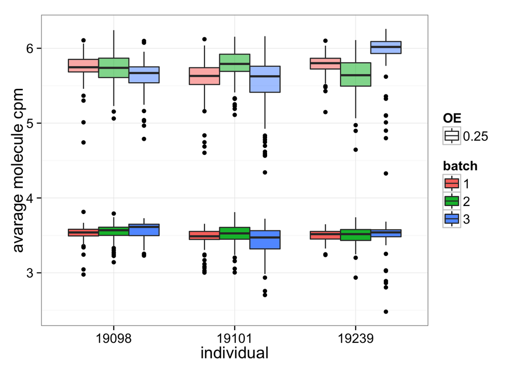

[figure not shown]

## Distribution of OE genes

```r
cutoffs <- seq(1001, nrow(molecules_single_cpm), by = 1000)
cutoffs <- c(cutoffs, nrow(molecules_single_cpm))
top_genes_count <- lapply(1:length(cutoffs), function(cut) {
                        per_cutoff <- cutoffs[cut]
                        cell_across_order <- order(rowSums(molecules_single_cpm), decreasing = TRUE)
                        top_genes <- rownames(molecules_single_cpm)[cell_across_order < per_cutoff]
                        sum(OE_raw$genes %in% top_genes)
                        })
top_genes_count <- do.call(c, top_genes_count)

ggplot(data.frame(top_count = top_genes_count,
                  cutoffs = cutoffs),
       aes(x = as.factor(cutoffs), y = top_count)) + geom_point() +
       labs(x = "Top X genes", y = "Number of OEFinder OE genes")
```

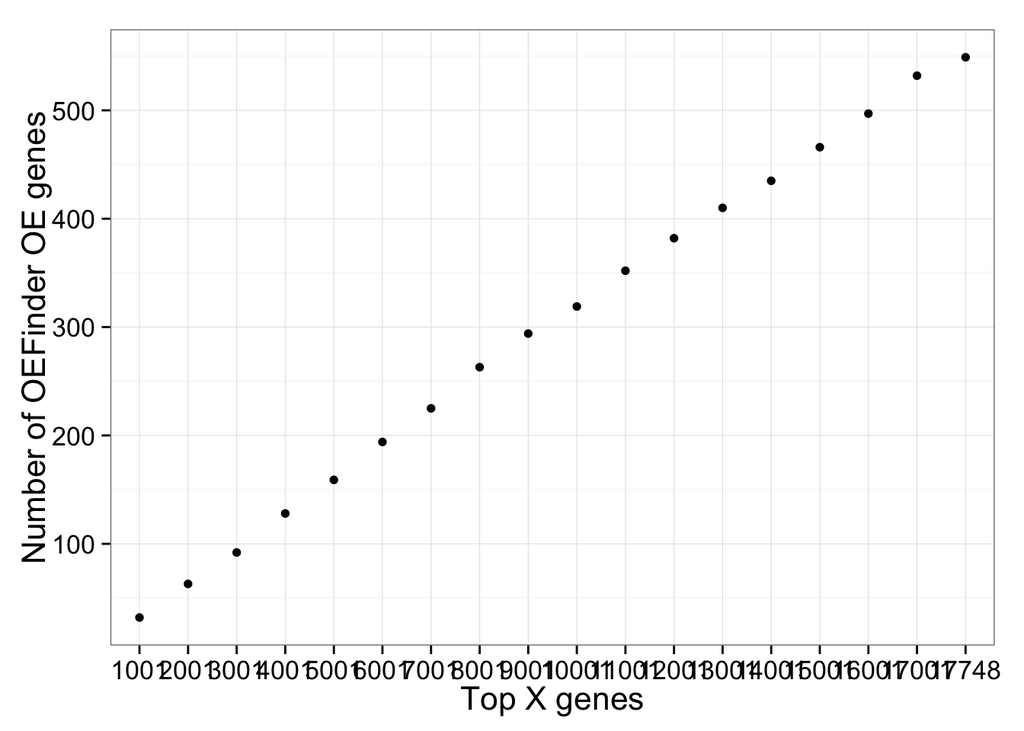

[figure not shown]

OE genes identified by OEFinder were not limited to the top 1000 genes. On the contrary, we found OE genes at all levels of gene expression (averaged acrosss cells).